# Fit Polynomial Respiration Model

Hao-Ran Wu ( haoranwu @ zju.edu.cn )

2022-09-17

In this section we are concerned about how to fit polynomial respiration models through the function `respir.fit()`.

## Code Example(s)

```r
# Fit Polynomial Respiration Models
# ********************************
#
# Fit polynomial respiration models from field measurements of soil temperature at
# 5cm, soil moisture at 10 cm, and soil respiration, at a larch forest in Mt. Fuji
# in 2015. Data provided by Dr. Naishen Liang (Email: liang@nies.go.jp)
#
# ********************************
# List of variables and units for this example
#
# 'path'        path of a CSV file, which contains four columns (with table titles)
#                * column 1(time):   a character representing observed time
#                * column 2(t_s):    soil temperature (Celsius)
#                * column 3(theta):  soil water content (%). Valid from 0-100
#                * column 4(Rs):     ecosystem respiration (µmol CO2 m−2 s−1)
#
# ********************************
# Step 1: import package
require(bproce)

# Step 2: choose parameters
path  <- "./data/3-1 Soil Respiration Measurements in Mt. Fuji.csv"

# Step 3: read data
dat   <- read.csv(path) # read the CSV file
                  #  * column 1 ($time): a character representing observed time
                  #  * column 2 ($t_s): temperature (Celsius)
                  #  * column 3 ($theta): soil water content (%). Valid from 0-100
                  #  * column 4 ($Rs): ecosystem respiration (µmol CO2 m−2 s−1)

# Step 4: fit the model
md_1st <- respir.fit(dat$Rs, dat$t_s, method = "t2.linear")
                  # fit linear model
md_2nd <- respir.fit(dat$Rs, dat$t_s, method = "t3.polynomial", n = 2)
                  # fit quadratic model
md_5st <- respir.fit(dat$Rs, dat$t_s, method = "t3.polynomial", n = 5)
                  # fit 5-th order polynomial model

cat(              # summarize the result (linear model)
  paste("***** Linear Model *****\n"),
  paste("a0 =", round(md_1st$coef[["a0"]], 3), "\n"),
  paste("a1 =", round(md_1st$coef[["a1"]], 3), "\n"),
  paste("Multiple R-square:", round(md_1st$r.squared, 3), "\n"),
  paste("Adjusted R-square:", round(md_1st$adj.r.squared, 3), "\n")
)

cat(              # summarize the result (quadratic model)
  paste("***** Quadratic Model *****\n"),
  paste("a0 =", round(md_2nd$coef[["a0"]], 3), "\n"),
  paste("a1 =", round(md_2nd$coef[["a1"]], 3), "\n"),
  paste("a2 =", round(md_2nd$coef[["a2"]], 3), "\n"),
  paste("Multiple R-square:", round(md_2nd$r.squared, 3), "\n"),
  paste("Adjusted R-square:", round(md_2nd$adj.r.squared, 3), "\n")
)

cat(              # summarize the result (5-th order polynomial model)
  paste("***** 5-th Order Polynomial Model *****\n"),
  paste("a0 =", round(md_5st$coef[["a0"]], 3), "\n"),
  paste("a1 =", round(md_5st$coef[["a1"]], 3), "\n"),
  paste("a2 =", round(md_5st$coef[["a2"]], 3), "\n"),
  paste("a3 =", round(md_5st$coef[["a3"]], 3), "\n"),
  paste("a4 =", round(md_5st$coef[["a4"]], 3), "\n"),
  paste("a5 =", round(md_5st$coef[["a5"]], 3), "\n"),
  paste("Multiple R-square:", round(md_5st$r.squared, 3), "\n"),
  paste("Adjusted R-square:", round(md_5st$adj.r.squared, 3), "\n")
)

# Step 5: model prediction
ta <- dat$t_s     # soil temperature at which respiration is to be predicted

## predict soil respiration (linear model)
a0 <- md_1st$coef[["a0"]]   # extract model parameter
a1 <- md_1st$coef[["a1"]]
predicted_Rs_linear <- eval(parse(text = md_1st$formula))    # make predictions

## predict soil respiration (quadratic model)
a0 <- md_2nd$coef[["a0"]]   # extract model parameter
a1 <- md_2nd$coef[["a1"]]
a2 <- md_2nd$coef[["a2"]]
predicted_Rs_quadratic <- eval(parse(text = md_2nd$formula)) # make predictions

## predict soil respiration (5-th order polynomial model)
a0 <- md_5st$coef[["a0"]]   # extract model parameter
a1 <- md_5st$coef[["a1"]]
a2 <- md_5st$coef[["a2"]]
a3 <- md_5st$coef[["a3"]]
a4 <- md_5st$coef[["a4"]]
a5 <- md_5st$coef[["a5"]]
predicted_Rs_5th <- eval(parse(text = md_5st$formula))       # make predictions

smoothScatter(
  dat$t_s, dat$Rs,
  xlab = "Soil Temperature at 5cm",
  ylab = "Soil Respiration",
  main = "Fit Polynomial Model",
  colramp = colorRampPalette(
    c("#EDFBFF","#D9F2FE","#C1E9FC","#B0E0FC","#9BD7FB","#87CEFA")
  )
)                       # soil respiration versus soil temperature
lines(dat$t_s, predicted_Rs_linear, col="#1874CD")   # linear model
lines(dat$t_s, predicted_Rs_quadratic, col="#8B0A50")# quadratic model
lines(dat$t_s, predicted_Rs_5th, col="#8B7355")      # 5-th order polynomial model
legend("bottomright", pch=c(15, 15, 15),
       col=c("#1874CD", "#8B0A50", "#8B7355"), bty="n",
       legend=c("Linear", "Quadratic", "5-th Polynomial"))   # add legends
```

## Explanation

**Step1:** Load the package `bproce` through the `require()` function.

```r
require(bproce)
```

**Step2:** Choose model parameters.

- `path`: the path of a CSV file which the data are to be read from. Each row of the file appears as one line, and columns are separated by commas (,). The first row appears as the table title. The sample file “3-1 Soil Respiration Measurements in Mt. Fuji.csv” contains four columns:
  - Column 1 (`$time`): A character representing observed time. The format is ‘dd/mm/yyyy hh:mm’, where ‘dd’ refers to day, ‘mm’ refers to month, and ‘yyyy’ refers to the year number. ‘hh’ refers to hour and ‘mm’ refers to minute. However, this column will not be used in this example.
  - Column 2 (`$t_s`): Soil temperature measured at 5cm (Celsius).
  - Column 3 (`$theta`): Soil water content (%). Valid from 0–100. However, this column will not be used in this example.
  - Column (`$Rs`): Measured soil respiration (µmol CO<sub>2</sub> m<sup>−2</sup> s<sup>−1</sup>).

```r
path  <- "./data/3-1 Soil Respiration Measurements in Mt. Fuji.csv"
```

**Step3:** Read data. Read the CSV file in table format and creates a data frame through the function `read.csv()`.

```r
dat   <- read.csv(path) # read the CSV file
                  #  * column 1 ($time): a character representing observed time
                  #  * column 2 ($t_s): temperature (Celsius)
                  #  * column 3 ($theta): soil water content (%). Valid from 0-100
                  #  * column 4 ($Rs): ecosystem respiration (µmol CO2 m−2 s−1)

head(dat)         #print first parts of the data
```

```
              time   t_s theta    Rs
1 18/03/2015 00:00 -1.35  23.4 0.568
2 18/03/2015 02:00 -1.41  23.2 0.500
3 18/03/2015 04:00 -1.50  23.0 0.298
4 18/03/2015 06:00 -1.36  22.8 0.237
5 18/03/2015 08:00 -1.15  22.7 0.269
6 18/03/2015 10:00 -1.38  22.5 0.551
```

**Step4:** Fit the model. Soil respiration ($R_s$, µmol CO<sub>2</sub> m<sup>−2</sup> s<sup>−1</sup>) can be modeled as a *n*-th order polynomial function of the temperature ($T$, <sup>o</sup>C) (Wofsy et al., 1993):

$$R=\beta_0+\beta_1·T+\beta_2·T^2+\beta_3·T^3+...+\beta_n·T^n,\quad(1)$$

```r
md_1st <- respir.fit(dat$Rs, dat$t_s, method = "t2.linear")
                  # fit linear model
md_2nd <- respir.fit(dat$Rs, dat$t_s, method = "t3.polynomial", n = 2)
                  # fit quadratic model
md_5st <- respir.fit(dat$Rs, dat$t_s, method = "t3.polynomial", n = 5)
                  # fit 5-th order polynomial model
```

Now summarize the model fit:

```r
cat(              # summarize the result (linear model)
  paste("***** Linear Model *****\n"),
  paste("a0 =", round(md_1st$coef[["a0"]], 3), "\n"),
  paste("a1 =", round(md_1st$coef[["a1"]], 3), "\n"),
  paste("Multiple R-square:", round(md_1st$r.squared, 3), "\n"),
  paste("Adjusted R-square:", round(md_1st$adj.r.squared, 3), "\n")
)
```

```
***** Linear Model *****
 a0 = -0.249
 a1 = 0.269
 Multiple R-square: 0.752
 Adjusted R-square: 0.752
```

```r
cat(              # summarize the result (quadratic model)
  paste("***** Quadratic Model *****\n"),
  paste("a0 =", round(md_2nd$coef[["a0"]], 3), "\n"),
  paste("a1 =", round(md_2nd$coef[["a1"]], 3), "\n"),
  paste("a2 =", round(md_2nd$coef[["a2"]], 3), "\n"),
  paste("Multiple R-square:", round(md_2nd$r.squared, 3), "\n"),
  paste("Adjusted R-square:", round(md_2nd$adj.r.squared, 3), "\n")
)
```

```
***** Quadratic Model *****
 a0 = 0.317
 a1 = 0.123
 a2 = 0.007
 Multiple R-square: 0.775
 Adjusted R-square: 0.775
```

```r
cat(              # summarize the result (5-th order polynomial model)
  paste("***** 5-th Order Polynomial Model *****\n"),
  paste("a0 =", round(md_5st$coef[["a0"]], 3), "\n"),
  paste("a1 =", round(md_5st$coef[["a1"]], 3), "\n"),
  paste("a2 =", round(md_5st$coef[["a2"]], 3), "\n"),
  paste("a3 =", round(md_5st$coef[["a3"]], 3), "\n"),
  paste("a4 =", round(md_5st$coef[["a4"]], 3), "\n"),
  paste("a5 =", round(md_5st$coef[["a5"]], 3), "\n"),
  paste("Multiple R-square:", round(md_5st$r.squared, 3), "\n"),
  paste("Adjusted R-square:", round(md_5st$adj.r.squared, 3), "\n")
)
```

```
***** 5-th Order Polynomial Model *****
 a0 = 0.857
 a1 = 0.181
 a2 = -0.087
 a3 = 0.013
 a4 = -0.001
 a5 = 0
 Multiple R-square: 0.833
 Adjusted R-square: 0.832
```

where `a0`, `a1`, … corresponds to $\beta_0$, $\beta_1$, … in equation (1).

**Step5:** Model prediction. Predict $R_s$ using the fitted model:

```r
ta <- dat$t_s     # soil temperature at which respiration is to be predicted

## predict soil respiration (linear model)
a0 <- md_1st$coef[["a0"]]   # extract model parameter
a1 <- md_1st$coef[["a1"]]
predicted_Rs_linear <- eval(parse(text = md_1st$formula))    # make predictions

## predict soil respiration (quadratic model)
a0 <- md_2nd$coef[["a0"]]   # extract model parameter
a1 <- md_2nd$coef[["a1"]]
a2 <- md_2nd$coef[["a2"]]
predicted_Rs_quadratic <- eval(parse(text = md_2nd$formula)) # make predictions

## predict soil respiration (5-th order polynomial model)
a0 <- md_5st$coef[["a0"]]   # extract model parameter
a1 <- md_5st$coef[["a1"]]
a2 <- md_5st$coef[["a2"]]
a3 <- md_5st$coef[["a3"]]
a4 <- md_5st$coef[["a4"]]
a5 <- md_5st$coef[["a5"]]
predicted_Rs_5th <- eval(parse(text = md_5st$formula))       # make predictions

print(head(data.frame(
  t_s = dat$t_s,                       # column 1: soil temperature
  linear = predicted_Rs_linear,        # column 2: Rs by linear model
  quadratic = predicted_Rs_quadratic,  # column 3: Rs by quadratic model
  fifth = predicted_Rs_5th             # column 4: Rs by 5-th order polynomial
)), digits = 3)
```

```
    t_s linear quadratic fifth
1 -1.35 -0.611     0.163 0.422
2 -1.41 -0.628     0.156 0.392
3 -1.50 -0.652     0.147 0.345
4 -1.36 -0.614     0.162 0.417
5 -1.15 -0.558     0.184 0.514
6 -1.38 -0.620     0.160 0.407
```

Create a plot of $R_s$ against $t_s$ to compare observed and predicted values:

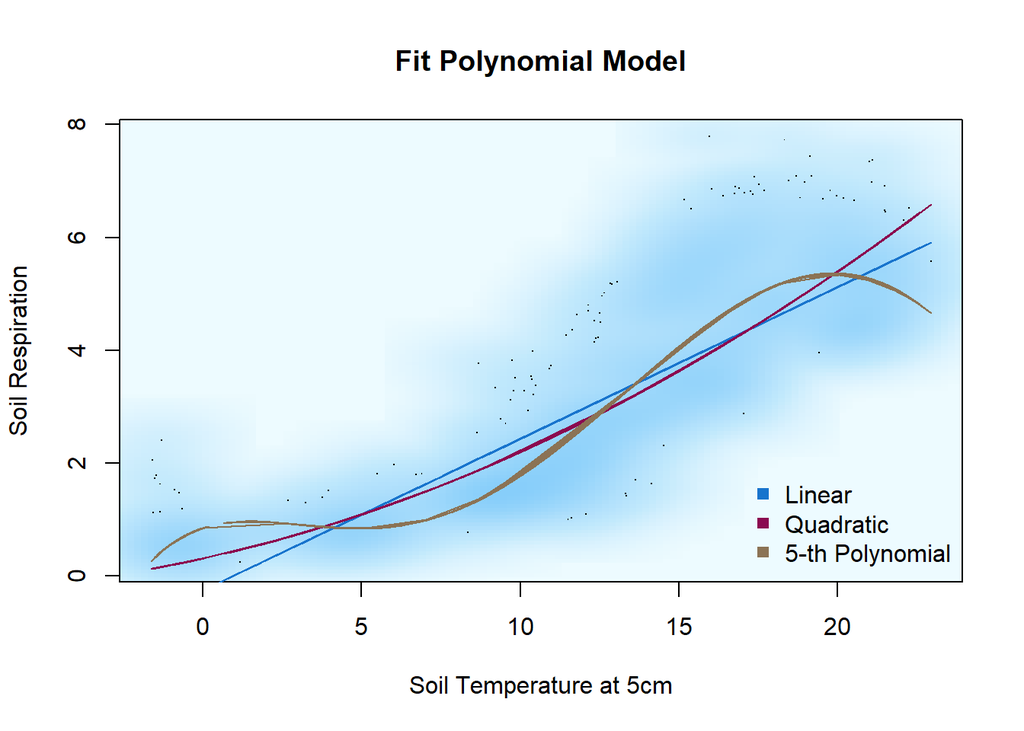

```r
smoothScatter(
  dat$t_s, dat$Rs,
  xlab = "Soil Temperature at 5cm",
  ylab = "Soil Respiration",
  main = "Fit Polynomial Model",
  colramp = colorRampPalette(
    c("#EDFBFF","#D9F2FE","#C1E9FC","#B0E0FC","#9BD7FB","#87CEFA")
  )
)                       # soil respiration versus soil temperature
lines(dat$t_s, predicted_Rs_linear, col="#1874CD")   # linear model
lines(dat$t_s, predicted_Rs_quadratic, col="#8B0A50")# quadratic model
lines(dat$t_s, predicted_Rs_5th, col="#8B7355")      # 5-th order polynomial model
legend("bottomright", pch=c(15, 15, 15),
       col=c("#1874CD", "#8B0A50", "#8B7355"), bty="n",
       legend=c("Linear", "Quadratic", "5-th Polynomial"))   # add legends
```

Function `smoothScatter` creates a high density scatter plot. The areas colored bright blue are those with the highest concentration of observed points, whilst the solid curve represents the fitted curve.

## Reference

Wofsy, S. C., Goulden, M. L., Munger, J. W., Fan, S. M., Bakwin, P. S., Daube, B. C., Bassow, S. L., and Bazzaz, F. A. (1993). Net exchange of CO2 in a mid-latitude forest. Science, 260(5112), 1314–1317.